# AFA - 4th Session

Mathis Mourey

28 octobre 2020

## Pricing Option

We starts today’s lecture by pricing exotic options using Monte-Carlo procedure. MC for pricing options consists in the following steps:

1. Choose a process for the underlying asset. Usually, we go for a Geometric Brownian Motion (GBM).
2. Simulate *n* price paths. In other words simulate the full development of the price from $t=0$ to $t=T$, *n* number of times.
3. Compute the payoff of the option at maturity (or $t=T$) for each simulation.
4. Average the payoff and discount it, in order to bring back the value to present days.

We start by choosing the process for our underlying asset. We choose a common GBM, such that the returns of our underlying follows:

$$\frac{dS_t}{S_t} = \mu * dt + \sigma * dB_t$$
We solve the PDE and we end up with the following closed-form:

$$S_{t + dt} = S_t e^{(\mu - \frac{\sigma^2}{2})dt + \sigma \epsilon \sqrt{dt}}$$
Where, $\epsilon$ is Standard White noise (eq. follows a Standard Gaussian (0, 1)).

In order to compute $\mu$ (the mean return) and $\sigma$ (the standard deviation of returns), we take the stock price of FB. Then we simulate `nb_mc` number of simulations.

```r
nb_mc = 50
df_mc = data.frame(matrix(NA, nrow=500, ncol=nb_mc))
x = getSymbols('FB', env=NULL )
```

[output not shown]

```r
#take only the 500 last points of the data
df_mc[,1]= tail(index(x), 500)
df_mc[,2] = tail(x[, 6], 500)


#get the mean and std of returns
mu= mean(diff(log(df_mc[,2])), na.rm=T)
sigma = sd(diff(log(df_mc[,2])), na.rm=T)

for(j in 3:(ncol(df_mc)-1)){
  df_mc[249,j] = df_mc[249,2]
  for(i in 250:500){
    df_mc[i, j] = df_mc[i-1,j]*exp((mu-(sigma**2)/2)+sigma*rnorm(1,0,1))
  }
}

df_mc[,nb_mc] = apply(X=df_mc[,3:(nb_mc-1)], FUN='mean', MARGIN = 1)
tail(df_mc)
```

```
##             X1     X2       X3       X4       X5       X6       X7
## 495 2020-12-09 277.92 277.6465 454.4927 508.4383 191.8730 251.3429
## 496 2020-12-10 277.12 265.9127 439.4191 513.3312 195.4805 259.7392
## 497 2020-12-11 273.55 264.8103 415.4052 515.7233 199.0858 260.0015
## 498 2020-12-14 274.19 264.7787 384.0908 501.3234 201.8645 255.8652
## 499 2020-12-15 275.55 264.4635 381.5758 500.7303 199.5158 240.8369
## 500 2020-12-16 275.67 271.7288 378.7209 498.4073 191.7908 247.1493
##           X8       X9      X10      X11      X12      X13      X14
## 495 199.5877 203.6227 263.2061 509.0290 368.0556 301.1335 345.1375
## 496 198.6076 212.5532 261.4028 508.4453 375.3252 304.5310 339.1902
## 497 203.2795 220.5686 267.0124 484.9175 370.5099 308.1577 340.2019
## 498 195.4637 217.5692 262.3358 482.0265 360.2392 308.5931 338.3752
## 499 204.1907 209.8847 267.4516 486.2279 342.2059 302.6971 335.9526
## 500 216.1763 202.2294 264.5064 482.0118 345.0972 302.3675 323.7296
##          X15      X16      X17      X18      X19      X20      X21
```

[output cut: 41 more lines]

By using the function `melt()` we allow to create the following graph that integrates all simulated future prices along with the actual one.

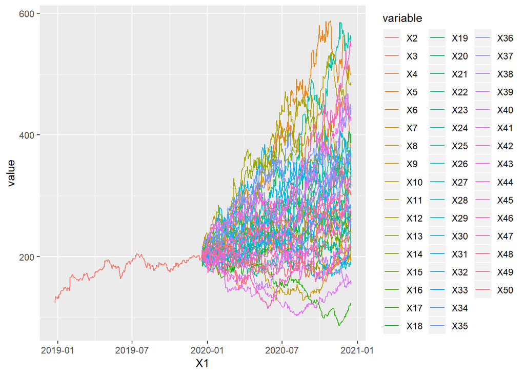

```r
new_df = melt(df_mc, id='X1')

p = ggplot() + geom_line(data=new_df, aes(x=X1, y=value, colour=variable))
p
```

We develop our program to price exotic option and price an example of Lookback option:

```r
Lookback_opt_pricer <- function(S, rf, t, sigma, option_type, nb_simu, time_step){
  dt = t/time_step
  drift = (rf-(sigma**2)/2)*dt
  shock = sigma*sqrt(dt)

  LB_Brownian = data.frame(matrix(nrow=time_step, ncol=nb_simu))
  LB_Brownian[1,] = rep(S, nb_simu)

  for(j in 1:nb_simu ){
    for(i in 2:time_step){
      LB_Brownian[i,j] = LB_Brownian[i-1,j]*exp(drift+shock*rnorm(1))

    }
  }

  pre_LB = colMeans(LB_Brownian)
  ST = LB_Brownian[time_step,]

  if(option_type=='call'){
    temp = pmax((ST-pre_LB),0)
    LB = sum(temp)/length(temp)
  } else {
    temp= pmax((pre_LB - ST),0)
    LB = sum(temp)/length(temp)
  }
  return(LB*(1+rf)**(-t))
}


Lookback_opt_pricer(S=100, rf=0.04, t=1, sigma=0.1, option_type='put', nb_simu=100, time_step=50)
```

```
## [1] 1.231113
```